# Does There Exist Inequality in Academic Achievement? - PISA 2012

## by Gabriel Barros

## Investigation Overview

In this investigation, I wanted to look at whether there is inequality in academic achievement. The main focus was on how the country where the student studies and the parents' situation are related to the academic performance.

## Dataset Overview

PISA is a survey of students' skills and knowledge as they approach the end of compulsory education. It is not a conventional school test. Rather than examining how well students have learned the school curriculum, it looks at how well prepared they are for life beyond school.

Around 490,000 students in 65 economies took part in the PISA 2012 assessment of reading, mathematics and science representing about 28 million 15-year-olds globally. Approximately 22,5 thousand (~5%) data points were removed from the analysis due to inconsistencies or missing information.

## PISA Methodology

PISA, as an international survey, report student performance through **plausible values**. A set of plausible values, usually five, are drawn for each student for each scale or subscale. Population statistics should be estimated using each plausible value separately. The reported population statistic is then the average of each plausible value statistic. *(PISA Data Analysis Manual: SPSS® SECOND EDITION)*

## Average of Student Performance by Country

Student performance is reported through 5 plausible values in the dataset, and each on can take on a range from 0 through 1,000. Aggregating the values by country, it's possible to see the average distribution in the world.

Looking at the world maps, it's clear that for all three scales (math, reading, and science) the highest averages concentrate in Europe, Oceania (Australia and New Zealand), North America (EUA and Canada), China, Japan and South Korea, i.e., rich countries.

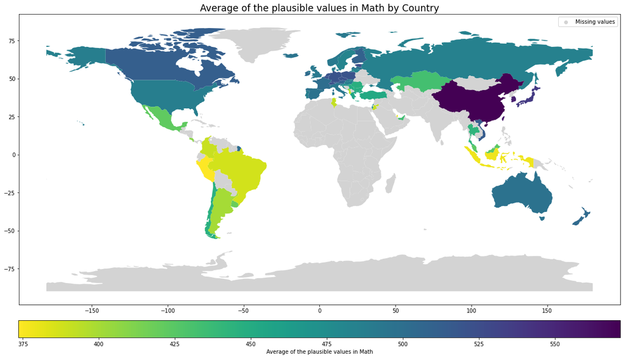

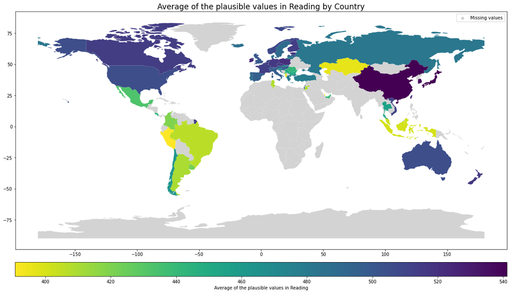

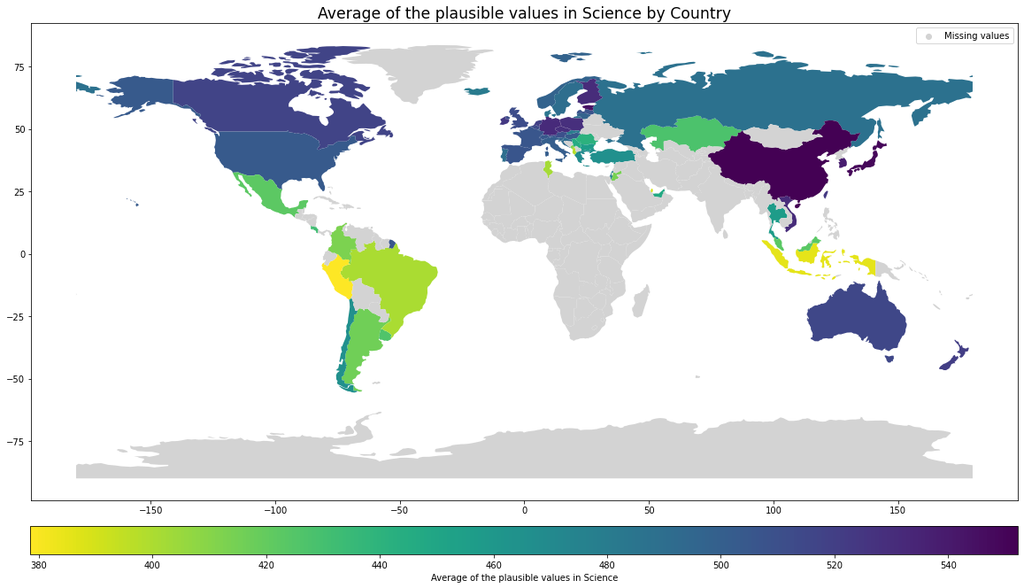

## Plausible Value 1 vs. Highest Parental Occupational Status

The Programme for International Student Assessment (PISA) International Socio-Economic Index of Occupational Status (ISEI) was derived from students' responses on parental occupation. The index captures the attributes of occupations that convert parents' education into income. *(Glossary Of Statistical Terms - OECD)*

Since the distributions of the 5 plausible values for each subject (math, reading, and science) are very similar to each other, there is no problem to just use the first plausible value of each subject to show the relationship between the highest parental occupational status and the plausible values.

We can see how the plausible values increase with the increase of the highest parental occupational status, a moderate positive relationship. In order to make the plots clearer and render faster, the plots used a sample of 10,000 students.

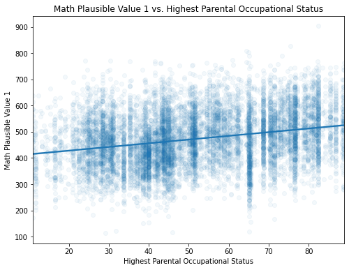

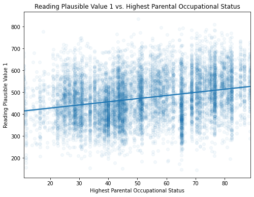

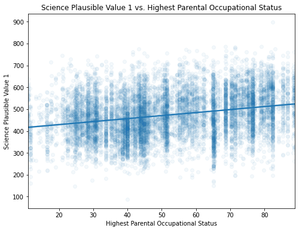

## Plausible Value 1 vs. Highest Parental Education in Years

Reproducing the same plots with the highest parental education in years, instead of the highest parental occupational status, shows, again, that the plausible values increase with the parental education time, a moderate positive relationship. Compared to the previous plots, however, it appears that the overall effect of education is greater compared to the ISEI.

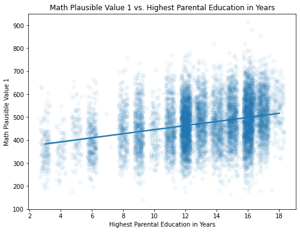

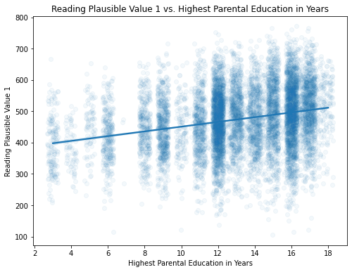

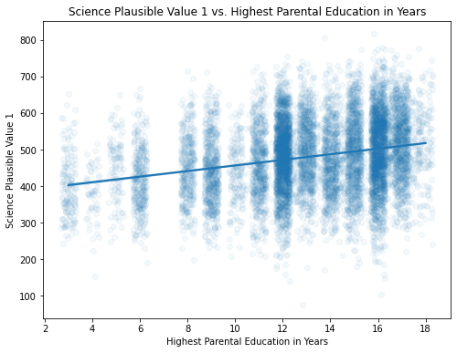

## Avg. of Student Performance vs. Highest Parental ISEI by Number of Computers at Home

We can see how the highest parental ISEI and number of computers at home affect the average of the plausible values of students. In each subject, students who do not have any computer to study at home have the lowest averages, regardless of their parents' ISEI.

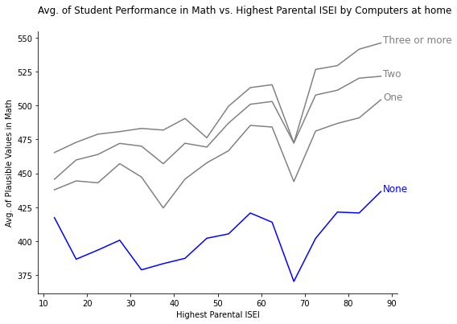

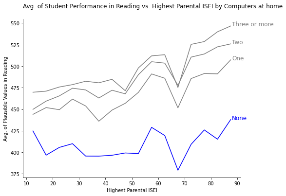

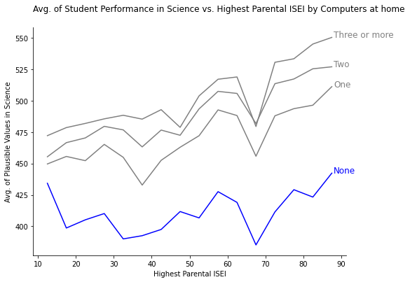

## Avg. of Student Performance vs. Highest Parental Education in Years by Number of Computers at Home

Reproducing the same plots with highest parental education in years instead of the highest parental ISEI shows, again, that, regardless of the parents' years of education, students who do not have any computer to study at home have the lowest averages in every single subject.

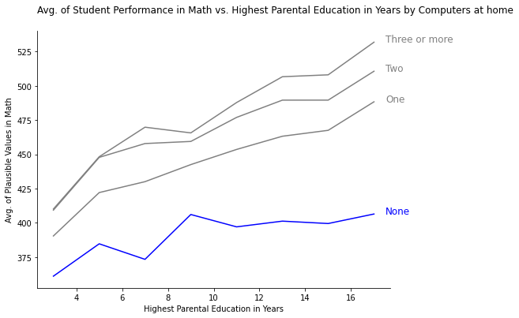

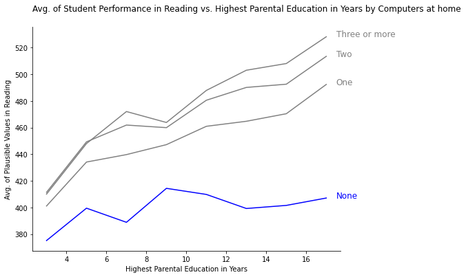

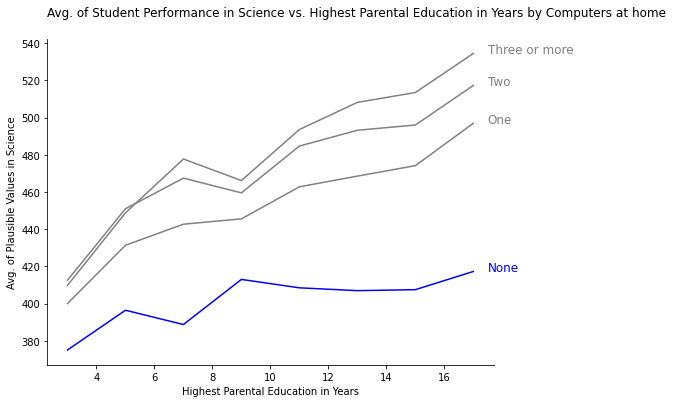